# Prediction

Ambroise Prevel, Olivier Rousseau, Antoine Moreau, Gustave Roche

15 March 2017

## Finalisation de la matrice de design

```r
design_mat <- read.csv("design_matrix_ambroise.csv")
```

L’input est une matrice contenant les colonnes suivantes:

```r
to_keep <- c("Référence",             #nom du produit (cf données Redken)
             "CA_mois",               #CA par mois (cf création de la matrice de design)
             "NbEmployes",            #Nb d'employés du salon (cf données Redken)
             "PrixColox",             #Prix de la couleur (cf données Redken)
             "MedianeNiveauDeVie",    #donnée INSEE de la commune du salon
             "CSP_Artisans_Commercants_ChefsEntreprises_percent", #donnée INSEE de la commune du salon
             "CSP_ProfessionsIntermediaires_percent", #donnée INSEE de la commune du salon
             "CSP_Ouvriers_percent",                  #donnée INSEE de la commune du salon
             "Pourcentage_chomeurs_dans_pop_active",  #donnée INSEE de la commune du salon
             "Pourcentage_autres_inactifs_dans_pop",  #donnée INSEE de la commune du salon
             "CSP_Agriculteurs_pourcentage",          #donnée INSEE de la commune du salon
             "CSP_CadresEtProfsIntellectuellesSup_percent", #donnée INSEE de la commune du salon
             "CSP_Employes_percent",                  #donnée INSEE de la commune du salon
             "Pourcentage_Hommes",                    #donnée INSEE de la commune du salon
             "Pourcentage_retraites_dans_pop"         #donnée INSEE de la commune du salon
             )
```

```r
design_mat2 <- design_mat[,to_keep]
```

Pour entrainer des régresseurs prédisant le chiffre d’affaire pour chaque produit, il nous faut avoir suffisamment de points de données pour ce produit. Le code ci-dessous nous permet de faire réaliser le comptage.

```r
count_prod <- NULL
for (prod in levels(design_mat2$Référence)){
  count_prod <- c(count_prod, a=dim(design_mat2[design_mat2$Référence==prod,])[1])
  names(count_prod)[length(count_prod)] <- prod
}
print(count_prod[1:15]) #on affiche les 15 premiers produits
```

```
##             A SFT COND 8.5OZ/250ML            A SFT HEAVY CREAM 250ML
##                                232                                250
##            A SFT SHMP 10.1OZ/300ML                  AERATE 3.2 OZ JAR
##                                437                                122
##                     ALIGN 12 150ML             ALL SOFT COND 500ML EU
##                                 12                                  1
##             ASOFT ARGAN 6 OIL 90ML           ASOFT SUPPLE TOUCH 150ML
##                                 75                                 86
##              BEACH ENVY COND 250ML         BEACH ENVY SHMP 300ML PB R
##                                  9                                 97
##         BEACH ENVY TRTMT 125ML SPR        BLONDE IDOL BBB SPRAY 150ML
##                                 96                                 67
## BLONDE IDOL DUAL COND VIOLET 196ML             BLONDE IDOL MASK 250ML
##                                 64                                126
##             BLONDE IDOL SHMP 300ML
##                                548
```

On ne garde que les produits pour lesquels on a plus de 100 pts de données.

```r
to_keep <- names(count_prod[count_prod>=100])
print(paste(length(to_keep), "conservés sur", length(levels(factor(design_mat2$Référence)))))
```

```
## [1] "57 conservés sur 113"
```

```r
design_mat2_partielle <- design_mat2[design_mat2$Référence %in% to_keep,]
```

## Entrainement des régresseurs

Nous créons une boucle qui, pour chaque produit conservé, va créer une matrice de variable explicatives *X* et un vecteur cible *y* (CA/mois), et entrainer un random forest pour prédire le CA/mois en fonction des données du salon.

```r
library(randomForest)
design_mat2_partielle$Référence <- factor(design_mat2_partielle$Référence) #supprimons les "levels" vides
produits <- levels(design_mat2_partielle$Référence) #récupérons la liste des produits
regressors <- list() #cette liste va stocker les regresseurs entraînés
for (prod in produits){                                                #pour chaque produit...
  X <- design_mat2_partielle[design_mat2_partielle$Référence==prod, 3:length(colnames(design_mat2_partielle))]                             #...on crée la matrice X...
  y <- design_mat2_partielle[design_mat2_partielle$Référence==prod, 2] #...et le vecteur y
  reg <- randomForest(X, y) #on entraine un random forest (500 arbres et une variable sur 3, par défaut)
  regressors[[prod]] <- reg #on stock le regresseur entrainé dans la liste
}
```

Il est intéressant de regarder l’importance des variables dans les regresseurs. Chaque régresseur peut renvoyer l’importance des variables sous forme de vecteur. Additionnons les vecteurs issus de chaque régresseur (et donc de chaque produit), renormalisons le résultat, et affichons un graphique montrant quelles sont les variables les plus importantes sur l’ensemble des produits.

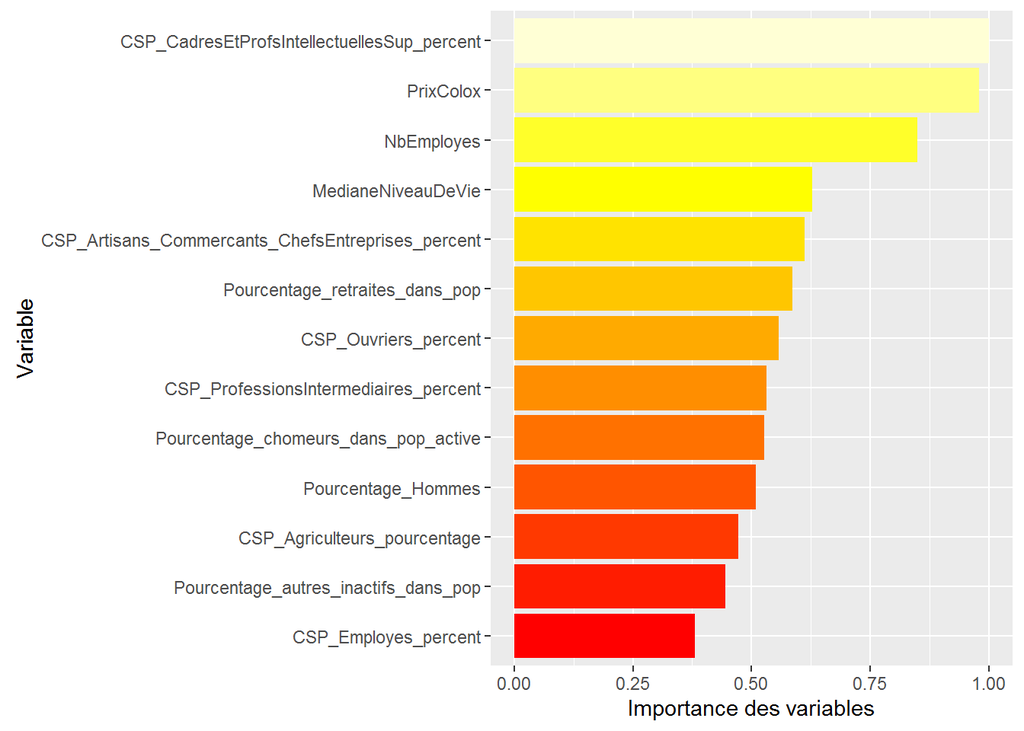

```r
library(ggplot2)
v_imp <- regressors[[1]]$importance*0

for (regr in regressors){
  v_imp <- v_imp + regr$importance
}
v_imp <- as.data.frame(v_imp/max(v_imp))

ggplot(data=v_imp)+geom_bar(aes(x=reorder(row.names(v_imp),IncNodePurity), y=IncNodePurity), stat="identity", fill=heat.colors(length(row.names(v_imp))))+coord_flip()+xlab("Variable")+ylab("Importance des variables")
```

## Reprédiction sur tous les magasins

```r
produits <- levels(factor(design_mat2_partielle$Référence)) #la liste des produits est toujours la même
```

On va créer une matrice des salonspour lesquels on veut des prédictions.

On veut donc toutes les colonnes de la matrice de design précédente (design_mat2), en dehors de la cible ( CA/mois) et de la référence du produit. On veut aussi rajouter le SIRET, pour pouvoir garder une trace.

```r
to_keep <- c("SIRET", colnames(design_mat2))               #on rajoute SIRET
to_keep <- to_keep[!to_keep%in%c("CA_mois", "Référence")]  #on enlève CA_mois et Référence
```

```r
a_predire <- unique(design_mat[,to_keep])  #on récupère tous les salons de la matrice du tout début
```

On récupère aussi la liste de tous les SIRET des salons pour lesquels prédire:

```r
salons <- levels(factor(a_predire$SIRET))
```

On crée un dataframe prêt à recevoir les prédictions. Il contient 3 colonnes:  
- SIRET (“SIRET”)  
- Référence produit (“Référence”)  
- Prédiction de CA/mois (“CA_mois_pred”) *pas encore complétée*

```r
produits_df <- data.frame("Référence"=produits)
SIRET_df <- data.frame("SIRET"=salons)
predictions <- merge(SIRET_df, produits_df, by=NULL) #produit cartésien des deux tableaux précédents
predictions$CA_mois_pred <- -1 #on crée la troisième colonne en la remplissante de -1
```

Pour chaque salon, on crée le vecteur de variables explicatives, et pour chaque produit, on fait prédire le régresseur correspondant. Le résultat est stocké dans le tableau créé précédemment.

```r
total_it <- length(salons)*length(produits) #on calcule le nombre de prédictions total
#ATTENTION, la boucle qui suit met plusieurs minutes à s'éxécuter
for(salon in salons){                            #pour chaque salon...
  X <- a_predire[a_predire$SIRET==salon,-c(1)]   #...on crée le vecteur de variables explicatives
  for(prod in produits){                             #pour chaque produit...
    prediction <- predict(regressors[[prod]], X)     #...on prédit le CA/mois réalisée par le salon
    #...et on stock le résultat à la bonne ligne du tableau
    predictions[(predictions$SIRET==salon)&(predictions$Référence==prod), "CA_mois_pred"] <- prediction
  }
}

#REMARQUE: code facilement améliorable en inversant le rôle de salons et produits dans la boucle. Cela nous permettrait d'utiliser la fonction predict sur des matrices contenant les données de plusieurs salons, et donc d'appeler cette fonctions beaucoup moins de fois.
```

Pour un salon existant donné, on peut voir les prédictions faites pour chaque produit:

```r
#exemple pour le salon de SIRET 437554710
df_437554710 <- predictions[(predictions$SIRET==437554710),]
df_437554710 <- df_437554710[order(-df_437554710$CA_mois_pred),] #on trie les produits en fonction du CA prédit
head(df_437554710, 10) #on affiche les 10 premiers
```

```
##           SIRET                    Référence CA_mois_pred
## 59575 437554710 TEMPORARY ROOT CONCEAL 2OZ T    129.98319
## 7734  437554710        CERA STEMOXYDINE 60ML     65.70461
## 37515 437554710  MEN'S WORK HARD POWER 100ML     49.09493
## 54060 437554710             ROUGH PASTE 75ML     48.48718
## 61781 437554710           WAX BLAST 10 150ML     45.04420
## 50751 437554710       RK CEXT MAG SHMP 300ML     42.49250
## 16558 437554710           CURV RINGLET 180ML     42.00161
## 43030 437554710           POWDER GRIP 03 7GR     41.72616
## 52957 437554710           ROUGH CLAY 20 50ML     41.25691
## 14352 437554710        CURV FULL SWIRL 150ML     38.28233
```

## Prédiction pour un nouveau salon

Si le salon est nouveau (nous n’avons que le prix de la coloration, le nombre d’employés et le code postal du salon), voici comment prédire:

```r
#prenons l'exemple d'un salon de la commune de Sainte Foy-lès-Lyon (69110), 3 employés, où le prix de la coloration est de 52€.

new_salon <- data.frame("Codepos"=69110, "NbEmployes"=3, "PrixColox"=52)

#on importe les données externes
ext <- read.csv("external_data.csv")

#on "colle" à notre nouveau salon les données correspondantes à sa commune
new_salon <- merge(new_salon, ext)

#on enlève les colonnes indésirables
new_salon <- new_salon[, !colnames(new_salon)%in%c("Codepos", "INSEE", "Nom.de.commune")]

#on passe toutes les colonnes en format numeric
for (i in 1:length(colnames(new_salon))){
  new_salon[,i] <- as.numeric(as.character(new_salon[,i]))
}

#on regarde si les colonnes sont bien dans le bon ordre (en comparant avec la variable X qui contient un input correct)
for(i in 1:13){print(paste(i, "####",colnames(X)[i], "####", colnames(new_salon)[i]))}
```

```
## [1] "1 #### NbEmployes #### NbEmployes"
## [1] "2 #### PrixColox #### PrixColox"
## [1] "3 #### MedianeNiveauDeVie #### Mediane.niveau.de.vie.2013"
## [1] "4 #### CSP_Artisans_Commercants_ChefsEntreprises_percent #### Agriculteurs.RP2013...."
## [1] "5 #### CSP_ProfessionsIntermediaires_percent #### Artisans..commerçants..chefs.d.entreprises.RP2013...."
## [1] "6 #### CSP_Ouvriers_percent #### Cadres.et.professions.intellectuelles.supérieures.RP2013...."
## [1] "7 #### Pourcentage_chomeurs_dans_pop_active #### Professions.intermédiaires.RP2013...."
## [1] "8 #### Pourcentage_autres_inactifs_dans_pop #### Employés.RP2013...."
## [1] "9 #### CSP_Agriculteurs_pourcentage #### Ouvriers.RP2013"
## [1] "10 #### CSP_CadresEtProfsIntellectuellesSup_percent #### X..hommes.dans.les.15.64..2013."
## [1] "11 #### CSP_Employes_percent #### X..de.chômeurs..dans.les.actifs...2013."
## [1] "12 #### Pourcentage_Hommes #### X..retraités.préretraités..2013."
## [1] "13 #### Pourcentage_retraites_dans_pop #### X..inactifs.non.retraités..2013."
```

```r
#on remets les colonnes dans le bon ordre
new_salon_X <- new_salon[,c(1,2,3,5,7,9,11,13,4,6,8,10,12)]

#on vérifie que ça a marché et on ajuste le nom des colonnes
for(i in 1:13){print(paste(i, "####",colnames(X)[i], "####", colnames(new_salon_X)[i]))}
```

```
## [1] "1 #### NbEmployes #### NbEmployes"
## [1] "2 #### PrixColox #### PrixColox"
## [1] "3 #### MedianeNiveauDeVie #### Mediane.niveau.de.vie.2013"
## [1] "4 #### CSP_Artisans_Commercants_ChefsEntreprises_percent #### Artisans..commerçants..chefs.d.entreprises.RP2013...."
## [1] "5 #### CSP_ProfessionsIntermediaires_percent #### Professions.intermédiaires.RP2013...."
## [1] "6 #### CSP_Ouvriers_percent #### Ouvriers.RP2013"
## [1] "7 #### Pourcentage_chomeurs_dans_pop_active #### X..de.chômeurs..dans.les.actifs...2013."
## [1] "8 #### Pourcentage_autres_inactifs_dans_pop #### X..inactifs.non.retraités..2013."
## [1] "9 #### CSP_Agriculteurs_pourcentage #### Agriculteurs.RP2013...."
## [1] "10 #### CSP_CadresEtProfsIntellectuellesSup_percent #### Cadres.et.professions.intellectuelles.supérieures.RP2013...."
## [1] "11 #### CSP_Employes_percent #### Employés.RP2013...."
## [1] "12 #### Pourcentage_Hommes #### X..hommes.dans.les.15.64..2013."
## [1] "13 #### Pourcentage_retraites_dans_pop #### X..retraités.préretraités..2013."
```

```r
colnames(new_salon_X) <- colnames(X)

#on fait la prédiction pour tous les produits
pred <- NULL
for(prod in produits){
  pred <- c(pred, predict(regressors[[prod]], new_salon_X))
}
predictions_new <- data.frame("Référence"=produits, "CA_mois_pred"=pred)

#on affiche le top 10 des produits en fonction avec la meilleure prédiction
head(predictions_new[order(-predictions_new$CA_mois_pred),],10)
```

```
##                       Référence CA_mois_pred
## 55 TEMPORARY ROOT CONCEAL 2OZ T    283.75032
## 10      CERAFILL DENSE FX 125ML     47.25207
## 42           QUICK DRY 18 500ML     44.25630
## 49           ROUGH CLAY 20 50ML     43.55087
## 50             ROUGH PASTE 75ML     42.47294
## 35  MEN'S WORK HARD POWER 100ML     41.06421
## 56      TRIPLE TAKE 32 300ML EU     40.27428
## 33       HIGH RISE STYLER 150ML     39.68891
## 57           WAX BLAST 10 150ML     37.34001
## 8         CERA STEMOXYDINE 60ML     36.58281
```